# Identifying Fraudulent Activities

**Challenge #1: Identifying Fraudulent Activities in transactional data**

```python
import pandas as pd
import pandasql as sql
import numpy as np
import matplotlib.pyplot as plt
import seaborn as sns
from sklearn.metrics import fbeta_score
from sklearn.metrics import accuracy_score
%matplotlib inline

# Reading the data files
user_data = pd.read_csv('Data/Fraud_Data.csv')
ipAddresstoCountry = pd.read_csv('Data/IpAddress_to_Country.csv')
```

```python
user_data.head()
```

|  | user_id | signup_time | purchase_time | purchase_value | device_id | source | browser | sex | age | ip_address | class |
| --- | --- | --- | --- | --- | --- | --- | --- | --- | --- | --- | --- |
| 0 | 22058 | 2015-02-24 22:55:49 | 2015-04-18 02:47:11 | 34 | QVPSPJUOCKZAR | SEO | Chrome | M | 39 | 7.327584e+08 | 0 |
| 1 | 333320 | 2015-06-07 20:39:50 | 2015-06-08 01:38:54 | 16 | EOGFQPIZPYXFZ | Ads | Chrome | F | 53 | 3.503114e+08 | 0 |
| 2 | 1359 | 2015-01-01 18:52:44 | 2015-01-01 18:52:45 | 15 | YSSKYOSJHPPLJ | SEO | Opera | M | 53 | 2.621474e+09 | 1 |
| 3 | 150084 | 2015-04-28 21:13:25 | 2015-05-04 13:54:50 | 44 | ATGTXKYKUDUQN | SEO | Safari | M | 41 | 3.840542e+09 | 0 |
| 4 | 221365 | 2015-07-21 07:09:52 | 2015-09-09 18:40:53 | 39 | NAUITBZFJKHWW | Ads | Safari | M | 45 | 4.155831e+08 | 0 |

```python
user_data.shape
```

```
(151112, 11)
```

```python
ipAddresstoCountry.head()
```

|  | lower_bound_ip_address | upper_bound_ip_address | country |
| --- | --- | --- | --- |
| 0 | 16777216.0 | 16777471 | Australia |
| 1 | 16777472.0 | 16777727 | China |
| 2 | 16777728.0 | 16778239 | China |
| 3 | 16778240.0 | 16779263 | Australia |
| 4 | 16779264.0 | 16781311 | China |

```python
ipAddresstoCountry.shape
```

```
(138846, 3)
```

Creating a function for mapping the user's IP Address to a country based on the ip address range

```python
def match_IP_to_Country(ipAddress=None):
    condition = (ipAddress >= ipAddresstoCountry['lower_bound_ip_address']) & (ipAddress <= ipAddresstoCountry['upper_bound_ip_address'])
    if condition.any():
        return ipAddresstoCountry['country'][condition].to_string(index=False)
    else:
        return 'unknown'
```

```python
user_data['country'] = user_data['ip_address'].apply(lambda x: match_IP_to_Country(x))
```

```python
user_data.head()
```

|  | user_id | signup_time | purchase_time | purchase_value | device_id | source | browser | sex | age | ip_address | class | country |
| --- | --- | --- | --- | --- | --- | --- | --- | --- | --- | --- | --- | --- |
| 0 | 22058 | 2015-02-24 22:55:49 | 2015-04-18 02:47:11 | 34 | QVPSPJUOCKZAR | SEO | Chrome | M | 39 | 7.327584e+08 | 0 | Japan |
| 1 | 333320 | 2015-06-07 20:39:50 | 2015-06-08 01:38:54 | 16 | EOGFQPIZPYXFZ | Ads | Chrome | F | 53 | 3.503114e+08 | 0 | United States |
| 2 | 1359 | 2015-01-01 18:52:44 | 2015-01-01 18:52:45 | 15 | YSSKYOSJHPPLJ | SEO | Opera | M | 53 | 2.621474e+09 | 1 | United States |
| 3 | 150084 | 2015-04-28 21:13:25 | 2015-05-04 13:54:50 | 44 | ATGTXKYKUDUQN | SEO | Safari | M | 41 | 3.840542e+09 | 0 | unknown |
| 4 | 221365 | 2015-07-21 07:09:52 | 2015-09-09 18:40:53 | 39 | NAUITBZFJKHWW | Ads | Safari | M | 45 | 4.155831e+08 | 0 | United States |

```python
user_data.signup_time = pd.to_datetime(user_data.signup_time)
user_data.purchase_time = pd.to_datetime(user_data.purchase_time)
```

```python
user_data.to_csv("user_country.csv",index=False)
```

**Exploratory Analysis**

Since this is a binary classification problem. Let us take a look at how balanced the dataset is.

```python
float(len(user_data[user_data["class"]==1]))/len(user_data)*100
```

```
9.364577267192546
```

Only 9.36% of all transactions are labeled as fraudulent. This shows that the dataset is highly imbalanced.Thus while building a model, we should watch out for false positives because classifying a legitimate user as a fraud could result in a bad user experience which could mean loss of revenue.

```python
# Checking if userid and ip addresses are unique
print sum(user_data.groupby("user_id").size() >1)
print sum(user_data.groupby("ip_address").size() >1)
```

```
0
760
```

```python
ip_address = user_data.groupby("ip_address").size().sort_values(ascending=False)
ip_address[ip_address>1]
```

```
ip_address
1.502818e+09    20
5.760609e+08    20
3.874758e+09    20
2.050964e+09    20
3.484934e+08    19
1.797069e+09    19
3.503224e+09    19
3.058785e+09    19
2.586669e+09    19
1.800550e+09    19
2.937899e+09    19
1.839748e+08    18
9.794124e+08    18
2.354318e+08    18
1.281304e+09    18
1.443896e+09    18
1.687739e+09    18
2.141692e+09    18
1.955530e+08    18
2.249217e+09    18
3.445652e+09    17
3.019711e+09    17
2.470359e+09    17
2.881396e+09    17
3.645562e+09    17
2.294137e+09    17
2.011989e+09    17
6.233199e+08    17
1.509973e+09    17
1.235453e+09    17
                ..
3.724149e+09     6
2.143014e+09     6
2.509895e+09     6
4.758070e+08     6
1.115559e+09     6
2.308443e+09     6
3.982971e+09     6
4.292714e+09     6
```

[output cut: 8 more lines]

```
1.819946e+09     5
3.334922e+09     5
1.411807e+09     5
3.695328e+09     5
1.535781e+09     5
1.907233e+09     5
3.807391e+09     5
3.520413e+09     4
2.395147e+09     4
1.343549e+09     4
1.181834e+09     4
1.786159e+09     3
2.295521e+09     3
3.804140e+09     2
Length: 760, dtype: int64
```

There are 760 ip addresses that have been repeatedly used by different users. The data records the first transaction made by the users.So multiple users are using the same ip address.

```python
#Let us check if this is true for device ID as well
device_id = user_data.groupby("device_id").size().sort_values(ascending=False)
device_id[device_id>1]
# Device Ids are also shared by users. These might come handy while performing feature engineering.
```

```
device_id
KIPFSCNUGOLDP    20
ITUMJCKWEYNDD    20
CQTUVBYIWWWBC    20
NGQCKIADMZORL    20
EQYVNEGOFLAWK    20
ZUSVMDEZRBDTX    20
BWSMVSLCJXMCM    19
EGLGSEGYPMMAM    19
IGKYVZDBEGALB    19
SDJQRPKXQFBED    19
CDFXVYHOIHPYP    19
XHZBVWFWHSGTQ    18
OGBNHQHDZLGFZ    18
FFWAQIABHGYJC    18
QVMVTZOIJDKNR    18
TAODVYWZTHMTO    18
RWZCXZTQUORQL    18
XJWEQEWCBRAKD    18
UFBULQADXSSOG    18
GTIYVLCMAYBFA    18
KPAAACGRQWYIK    18
XSEQHFFOYFICY    17
KGXODJJIWSJJE    17
KYVPIVGZBEXNK    17
UHCAPOHBEBXJW    17
HGVNRPOHIBZLJ    17
NMCSWSCOZQJUP    17
QRMOMDDTIIUVW    17
IRVIFDVZMRXOU    17
SUEKLSZWLASFR    17
                 ..
TJMIUGXRPGALZ     2
TQRYRUWRNHFZL     2
ZHJKRMSEDFUPG     2
JTLPIHXHBLIUQ     2
VUDFNOOPDRLXG     2
NLQHWNMQFDMPP     2
ZYPKBBYHNPZDI     2
GMXPGEWYQQRQE     2
```

[output cut: 8 more lines]

```
TRJWUZIXBZIMW     2
PTFCHEJTAFKUI     2
ZQEETQPWKTHCS     2
MZPCYBTSULTQL     2
VXLTGOFSVWQCA     2
NCYGQOAUURLVE     2
AJDIJMQWGMJUD     2
WLVTMNDCMBHRU     2
GPKYDCCNVNXZE     2
JCJNYQDFHMVQR     2
WGSBFHHRZWHAO     2
GSPBOBBHQPOAR     2
ZYPCCBNIVLCNK     2
JWHFKCRCLGVAY     2
Length: 6175, dtype: int64
```

Let us take a look at relationships between the outcome variable(class) and the rest of the features.

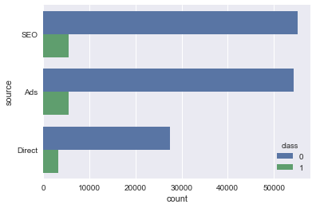

```python
sns.countplot(y="source",hue="class",data=user_data)
```

Source on its own doesn't seem to be quite predictive of whether the user transaction is fraudulent or not. Total transactions from "Direct" source are lesser as compared to the other two sources.

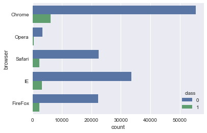

```python
sns.countplot(y="browser",hue="class",data=user_data)
```

Chrome seems to be very popular with the users and Opera seems to be the least popular. Again "browser" on its own does not have a lot of predictive popular.

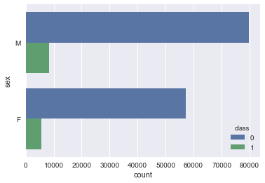

```python
sns.countplot(y="sex",hue="class",data=user_data)
```

Overall there are more male users when compared to females. But the propotion of fraudulent users for each sex category seems to be the same.

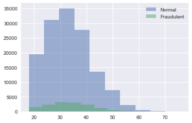

```python
plt.hist(user_data[user_data['class']==0].age,alpha=0.5,label='Normal')
plt.hist(user_data[user_data['class']==1].age,alpha=0.5,label='Fraudulent')
plt.legend()
plt.show()
```

Distribution of the age variable in the histogram shows that the majority of the users are between ages 20 and 40. The distribution of fraudulent vs non-fraudulent user ages is quite similar. Thus age also by itself is not a strong predictor for our classification task.

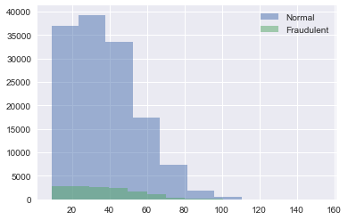

```python
plt.hist(user_data[user_data['class']==0].purchase_value,alpha=0.5,label='Normal')
plt.hist(user_data[user_data['class']==1].purchase_value,alpha=0.5,label='Fraudulent')
plt.legend()
plt.show()
```

As with age, the purchase value variable distribution is right skewed with majority of the transactions lying between 20-60.

```python
country_wise = user_data.groupby(["country","class"]).size().unstack()
country_wise.columns = ["No Fraud","Fraud"]
country_wise.sort_values("Fraud",ascending=False)
```

| country | No Fraud | Fraud |
| --- | --- | --- |
| United States | 52498.0 | 5551.0 |
| unknown | 20083.0 | 1883.0 |
| China | 10995.0 | 1043.0 |
| Japan | 6591.0 | 715.0 |
| United Kingdom | 4013.0 | 477.0 |
| Korea Republic of | 3782.0 | 380.0 |
| Canada | 2627.0 | 348.0 |
| France | 2861.0 | 300.0 |
| Brazil | 2691.0 | 270.0 |
| Germany | 3384.0 | 262.0 |
| Italy | 1778.0 | 166.0 |
| Australia | 1679.0 | 165.0 |
| India | 1159.0 | 151.0 |
| Mexico | 977.0 | 144.0 |
| Russian Federation | 1482.0 | 134.0 |
| Sweden | 959.0 | 131.0 |
| Netherlands | 1557.0 | 123.0 |
| Taiwan; Republic of China (ROC) | 1138.0 | 99.0 |
| Norway | 530.0 | 79.0 |
| Denmark | 412.0 | 78.0 |
| South Africa | 764.0 | 74.0 |
| Spain | 954.0 | 73.0 |
| Switzerland | 716.0 | 69.0 |
| Argentina | 595.0 | 66.0 |
| Chile | 353.0 | 64.0 |
| New Zealand | 216.0 | 62.0 |
| Hong Kong | 410.0 | 61.0 |
| Indonesia | 592.0 | 57.0 |
| Belgium | 353.0 | 56.0 |
| Ireland | 185.0 | 55.0 |
| ... | ... | ... |
| Macau | 10.0 | NaN |
| Madagascar | 1.0 | NaN |
| Maldives | 2.0 | NaN |
| Monaco | 3.0 | NaN |
| Mongolia | 6.0 | NaN |
| Mozambique | 16.0 | NaN |
| Myanmar | 1.0 | NaN |
| Nauru | 1.0 | NaN |
| Nepal | 18.0 | NaN |
| New Caledonia | 5.0 | NaN |
| Niger | 1.0 | NaN |
| Oman | 41.0 | NaN |
| Palestinian Territory Occupied | 16.0 | NaN |
| Papua New Guinea | 4.0 | NaN |
| Puerto Rico | 30.0 | NaN |
| Qatar | 25.0 | NaN |
| Reunion | 3.0 | NaN |
| Rwanda | 15.0 | NaN |
| Saint Kitts and Nevis | 2.0 | NaN |
| Saint Martin | 1.0 | NaN |
| San Marino | 1.0 | NaN |
| South Sudan | 1.0 | NaN |
| Syrian Arab Republic | 24.0 | NaN |
| Tajikistan | 1.0 | NaN |
| Tanzania United Republic of | 15.0 | NaN |
| Uganda | 13.0 | NaN |
| Vanuatu | 1.0 | NaN |
| Yemen | 1.0 | NaN |
| Zambia | 10.0 | NaN |
| Zimbabwe | 6.0 | NaN |

182 rows × 2 columns

There are 182 countries in the data set. Let us check what % of total transactions belong to these countries. Based on that we could take top n countries and bucket the rest of them to one category ("Others")

```python
x=user_data.groupby('country').size()*100/len(user_data)
x.sort_values(ascending=False)
```

```
country
United States                           38.414553
unknown                                 14.536238
China                                    7.966277
Japan                                    4.834825
United Kingdom                           2.971306
Korea Republic of                        2.754249
Germany                                  2.412780
France                                   2.091826
Canada                                   1.968738
Brazil                                   1.959474
Italy                                    1.286463
Australia                                1.220287
Netherlands                              1.111758
Russian Federation                       1.069405
India                                    0.866907
Taiwan; Republic of China (ROC)          0.818598
Mexico                                   0.741834
Sweden                                   0.721319
Spain                                    0.679628
South Africa                             0.554556
Switzerland                              0.519482
Poland                                   0.482424
Argentina                                0.437424
Indonesia                                0.429483
Norway                                   0.403012
Colombia                                 0.398380
Turkey                                   0.375880
Viet Nam                                 0.363968
Romania                                  0.347424
Denmark                                  0.324263
                                          ...
Reunion                                  0.001985
Congo The Democratic Republic of The     0.001985
Bhutan                                   0.001324
Lesotho                                  0.001324
Liechtenstein                            0.001324
Gibraltar                                0.001324
Maldives                                 0.001324
Benin                                    0.001324
```

[output cut: 8 more lines]

```
Dominica                                 0.000662
Niger                                    0.000662
Nauru                                    0.000662
Vanuatu                                  0.000662
Guadeloupe                               0.000662
Bonaire; Sint Eustatius; Saba            0.000662
Myanmar                                  0.000662
British Indian Ocean Territory           0.000662
Turkmenistan                             0.000662
Madagascar                               0.000662
Gambia                                   0.000662
Cape Verde                               0.000662
San Marino                               0.000662
Tajikistan                               0.000662
Length: 182, dtype: float64
```

```python
countries_to_keep = x[x>0.1].index.format()
```

**Feature Engineering** Some additional features that could be used are:

1. Time difference between signup and purchase time - To check for unusual activities or bot driven transaction
2. No. of users associated to a unique device_id
3. No. of users associated to a unique ip_address
4. Time related features extracted from signup date and purchase date such as year, month,week,day,hour etc.

```python
# Adding feature for difference in time between signup and purchase time
t1 = pd.to_datetime(user_data.purchase_time)
t2 = pd.to_datetime(user_data.signup_time)
user_data["difference"] = (t1 - t2).abs().dt.days
```

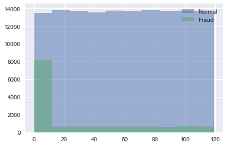

```python
plt.hist(user_data[user_data["class"]==0].difference,alpha=0.5,label="Normal")
plt.hist(user_data[user_data["class"]==1].difference,alpha=0.5,label="Fraud")
plt.legend()
plt.show()
```

```python
# Adding no. of user per ip address
ip_address_group = user_data.groupby("ip_address").size().reset_index()
ip_address_group.columns = ['ip_address','users_per_ip']
user_data_1 = pd.merge(user_data,ip_address_group,how='left',on="ip_address")
```

```python
# Adding no. of user per device id
device_id_group = user_data_1.groupby("device_id").size().reset_index()
device_id_group.columns = ['device_id','users_per_device']
user_data_1 = pd.merge(user_data_1,device_id_group,how='left',on="device_id")
```

```python
user_data_1.head()
```

|  | user_id | signup_time | purchase_time | purchase_value | device_id | source | browser | sex | age | ip_address | class | country | difference | users_per_ip | users_per_device |
| --- | --- | --- | --- | --- | --- | --- | --- | --- | --- | --- | --- | --- | --- | --- | --- |
| 0 | 22058 | 2015-02-24 22:55:49 | 2015-04-18 02:47:11 | 34 | QVPSPJUOCKZAR | SEO | Chrome | M | 39 | 7.327584e+08 | 0 | Japan | 52 | 1 | 1 |
| 1 | 333320 | 2015-06-07 20:39:50 | 2015-06-08 01:38:54 | 16 | EOGFQPIZPYXFZ | Ads | Chrome | F | 53 | 3.503114e+08 | 0 | United States | 0 | 1 | 1 |
| 2 | 1359 | 2015-01-01 18:52:44 | 2015-01-01 18:52:45 | 15 | YSSKYOSJHPPLJ | SEO | Opera | M | 53 | 2.621474e+09 | 1 | United States | 0 | 12 | 12 |
| 3 | 150084 | 2015-04-28 21:13:25 | 2015-05-04 13:54:50 | 44 | ATGTXKYKUDUQN | SEO | Safari | M | 41 | 3.840542e+09 | 0 | unknown | 5 | 1 | 1 |
| 4 | 221365 | 2015-07-21 07:09:52 | 2015-09-09 18:40:53 | 39 | NAUITBZFJKHWW | Ads | Safari | M | 45 | 4.155831e+08 | 0 | United States | 50 | 1 | 1 |

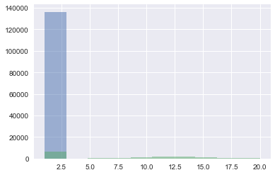

```python
plt.hist(user_data_1[user_data_1["class"]==0].users_per_ip,alpha=0.5,label="Normal")
plt.hist(user_data_1[user_data_1["class"]==1].users_per_ip,alpha=0.5,label="Normal")
plt.show()
```

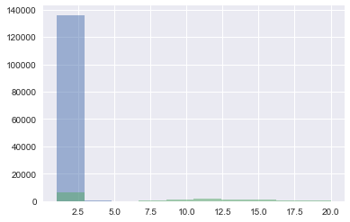

```python
plt.hist(user_data_1[user_data_1["class"]==0].users_per_device,alpha=0.5,label="Normal")
plt.hist(user_data_1[user_data_1["class"]==1].users_per_device,alpha=0.5,label="Normal")
plt.show()
```

Users per ip and per device also show a distinctive pattern of high fraud activity from ip addresses and devices are are shared by multiple users.

```python
#Extracting time components from Signup Date
user_data_1["Signup_month"] = t1.dt.month
user_data_1["Signup_day"] = t1.dt.day

#Extracting time components from Purchase Date
user_data_1["Purchase_month"] = t2.dt.month
user_data_1["Purchase_day"] = t2.dt.day
```

```python
user_data_1["Signup_month"]= user_data_1["Signup_month"].astype(str)
user_data_1["Signup_day"]= user_data_1["Signup_day"].astype(str)
user_data_1["Purchase_month"] = user_data_1["Purchase_month"].astype(str)
user_data_1["Purchase_day"] = user_data_1["Purchase_day"].astype(str)
```

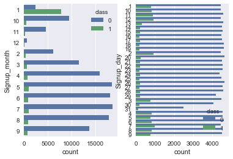

```python
fig, axs = plt.subplots(ncols=2)
sns.countplot(y="Signup_month",data=user_data_1,hue="class",ax=axs[0])
sns.countplot(y="Signup_day",data=user_data_1,hue="class",ax=axs[1])
```

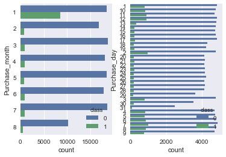

```python
fig, axs = plt.subplots(ncols=2)
sns.countplot(y="Purchase_month",data=user_data_1,hue="class",ax=axs[0])
sns.countplot(y="Purchase_day",data=user_data_1,hue="class",ax=axs[1])
```

The time component graphs show high fraudulent activity in January as compared to rest of the months. Also transactions occuring in the first 15 days of a month are more likely to be fraudulent from the above visuals.

**Machine Learning**

```python
# Split the data into features and target label
class_raw = user_data_1['class']
features_raw = user_data_1.drop(['class','user_id','signup_time','purchase_time','device_id','ip_address'], axis = 1)
```

```python
# users per ip address and device id are highly skewed
skewed = ['users_per_ip','users_per_device']
features_log_transformed = pd.DataFrame(features_raw)
features_log_transformed[skewed] = features_raw[skewed].apply(lambda x: np.log(x+1))
```

```python
features_log_transformed.head()
```

|  | purchase_value | source | browser | sex | age | country | difference | users_per_ip | users_per_device | Signup_month | Signup_day | Purchase_month | Purchase_day |
| --- | --- | --- | --- | --- | --- | --- | --- | --- | --- | --- | --- | --- | --- |
| 0 | 34 | SEO | Chrome | M | 39 | Japan | 52 | 0.693147 | 0.693147 | 4 | 18 | 2 | 24 |
| 1 | 16 | Ads | Chrome | F | 53 | United States | 0 | 0.693147 | 0.693147 | 6 | 8 | 6 | 7 |
| 2 | 15 | SEO | Opera | M | 53 | United States | 0 | 2.564949 | 2.564949 | 1 | 1 | 1 | 1 |
| 3 | 44 | SEO | Safari | M | 41 | unknown | 5 | 0.693147 | 0.693147 | 5 | 4 | 4 | 28 |
| 4 | 39 | Ads | Safari | M | 45 | United States | 50 | 0.693147 | 0.693147 | 9 | 9 | 7 | 21 |

```python
from sklearn.preprocessing import MinMaxScaler

# Initialize a scaler, then apply it to the features
scaler = MinMaxScaler() # default=(0, 1)
numerical = ['age', 'purchase_value', 'difference','users_per_ip','users_per_device']

features_log_minmax_transform = pd.DataFrame(data = features_log_transformed)
features_log_minmax_transform[numerical] = scaler.fit_transform(features_log_transformed[numerical])
```

```python
features_log_minmax_transform.dtypes
```

```
purchase_value      float64
source               object
browser              object
sex                  object
age                 float64
country              object
difference          float64
users_per_ip        float64
users_per_device    float64
Signup_month         object
Signup_day           object
Purchase_month       object
Purchase_day         object
dtype: object
```

```python
features_final = pd.get_dummies(features_log_minmax_transform)

# Print the number of features after one-hot encoding
encoded = list(features_final.columns)
print "{} total features after one-hot encoding.".format(len(encoded))
```

```
279 total features after one-hot encoding.
```

```python
from sklearn.model_selection import train_test_split
# Splitting the final_features to train and test data sets
X_train,X_test,y_train,y_test = train_test_split(features_final,
                                                class_raw,
                                                test_size=0.2,
                                                random_state=0)

print "Training set has {} rows".format(len(X_train))
print "Test set has {} rows".format(len(X_test))
```

```
Training set has 120889 rows
Test set has 30223 rows
```

```python
from sklearn.ensemble import GradientBoostingClassifier
clf = GradientBoostingClassifier(random_state=10)
clf.fit(X_train,y_train)
pred=clf.predict(X_test)
```

[output not shown]

```python
print "Accuracy Score: {}".format(accuracy_score(y_pred=pred,y_true=y_test))
print "Fbeta_score: {}".format(fbeta_score(beta=0.5,y_pred=pred,y_true=y_test))
```

```
Accuracy Score: 0.958839294577
Fbeta_score: 0.858789302898
```

```python
pred_prob = clf.predict_proba(X_test)[:,1]
```

[output not shown]

```python
from sklearn.metrics import roc_curve
from sklearn.metrics import auc
fpr,tpr,thresholds = roc_curve(y_test,pred_prob)
roc_auc = auc(fpr,tpr)
```

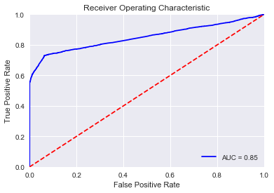

```python
plt.title('Receiver Operating Characteristic')
plt.plot(fpr, tpr, 'b', label = 'AUC = %0.2f' % roc_auc)
plt.legend(loc = 'lower right')
plt.plot([0, 1], [0, 1],'r--')
plt.xlim([0, 1])
plt.ylim([0, 1])
plt.ylabel('True Positive Rate')
plt.xlabel('False Positive Rate')
plt.show()
```

```python
from sklearn.metrics import confusion_matrix
confusion_matrix(y_test,pred)
```

```
array([[27444,     6],
       [ 1238,  1535]])
```